# Análise de Gastos dos Deputados

Júlio Guedes

August 29, 2018

### Importando as bibliotecas

```r
library(readr)
library(dplyr)
library(plyr)
library(ggplot2)
library(ggrepel)
library(gridExtra)
```

### Importando e padronizando os dados

```r
dadosCEAP <- read_csv("dadosCEAP.csv")
dadosCEAP$valorGlosa <- as.numeric(sub(",", ".", dadosCEAP$valorGlosa, fixed = TRUE))
limiteMensalCEAP <- read_csv("limiteMensalCEAP.csv")
```

### Questão 1: Quais são os deputados que gastaram mais dinheiro da CEAP? Quais são os mais econômicos?

Para responder a primeira pergunta, podemos mostrar um gráfico de barras com todos os gastos de deputados e observar o máximo e o mínimo:

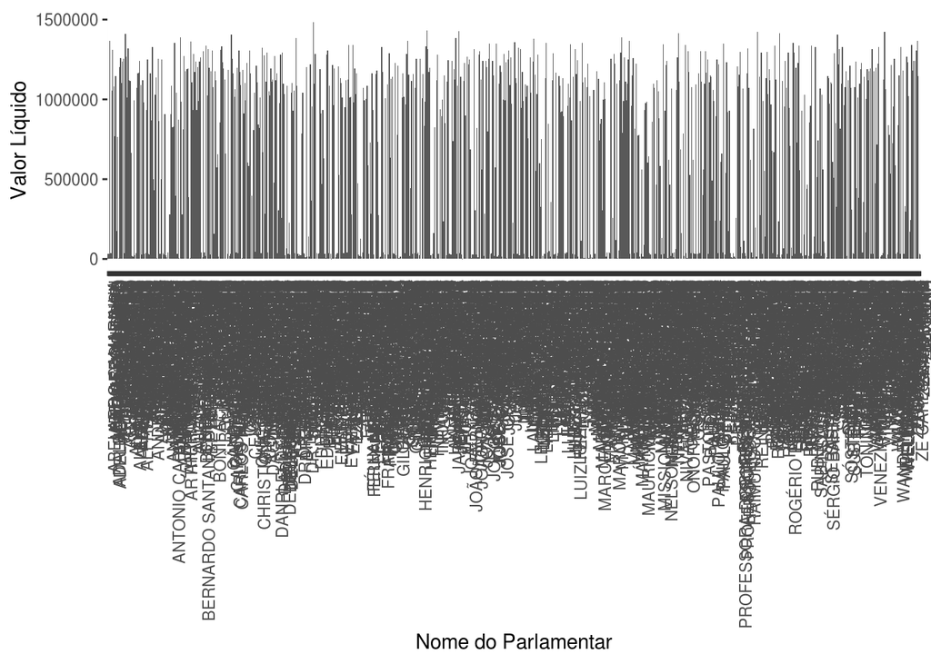

Entretanto, é difícil identificar o maior e menor em meio a tantas entradas, e ainda mais quando estão desordenadas. O próximo passo, então, é criar um gráfico ordenado para mostrar um subgrupo contendo n deputados, podendo ser os que mais gastaram ou que menos gastaram. Para isso, ordenar os dados antes de plotar:

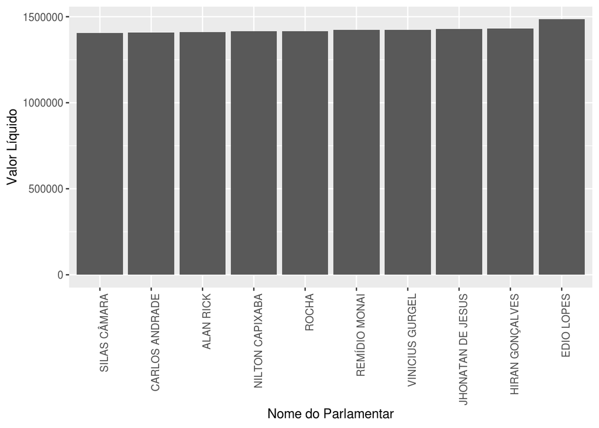

Por termos encontrado o top10 de deputados que mais gastam, podemos encontrar também o top10 deputados que menos gastam:

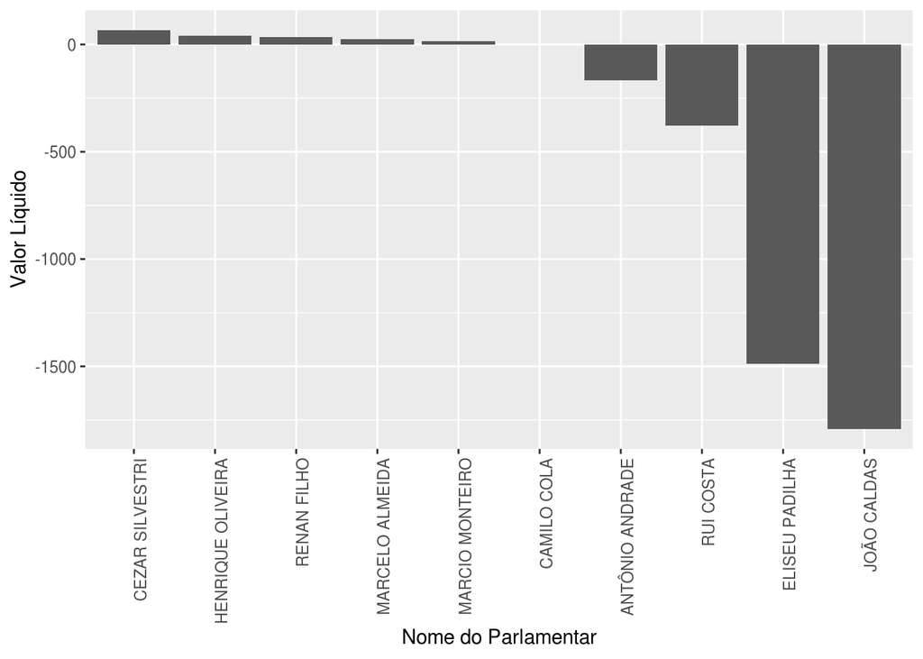

Inicialmente, a visualização assusta, “Como um gráfico de gastos pode ter valores negativos?”. Entretanto, já era previsto nos dados que, nos casos de passagem aérea, o valor poderia ser negativo, representando uma compensação ao Parlamentar, isto é, um bilhete de compensação.

### Questão 2: Quais os estados cujos deputados gastam mais no exterior? Quais os estados cujos deputados gastam menos no exterior?

Para responder essa questão, faremos basicamente o mesmo procedimento da questão anterior. Nos nosso dados, temos uma coluna identificando o tipo do Documento, que tem valor 2 quando foi de um gasto no exterior. Assim, é necessário filtrar as entradas que possuem esse valor na coluna, e repetir o procedimento da questão anterior, e para adiantar, já podemos plotar ordenado.

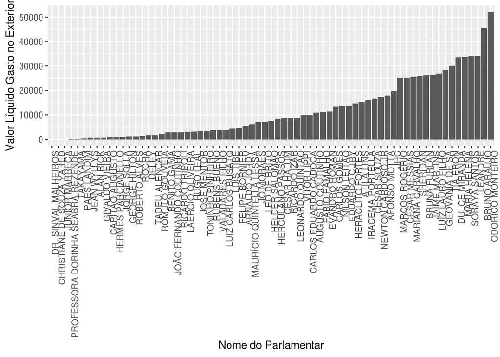

Nesse gráfico, já podemos observar mais de perto quem são os políticos que gastaram no exterior, podendo também ver que Odorico Monteiro quem mais gastou e Dr Sinval Malheiros quem menos gastou. Entretanto, ainda é justo analisarmos o top10 que mais e menos gastou no exterior:

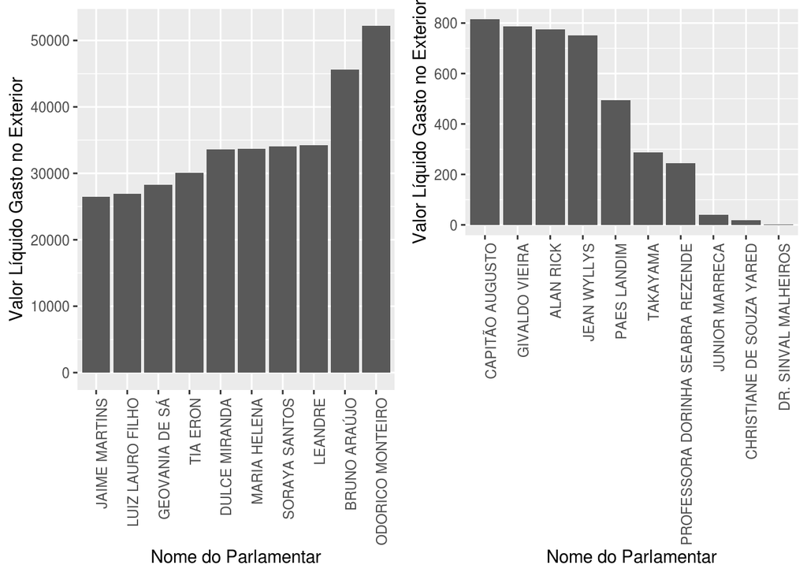

### Questão 3: Quais os partidos cujos parlamentares mais usam CEAP no estado da Paraíba? Quais são os que menos usam? Mesmas perguntas considerando valores em R$.

Para esta pergunta, poderíamos repetir os processos anteriores e plotar dois gráficos de barras. Entretanto, plotando um gráfico de pontos, sendo o eixo x a frequência de gastos, e o eixo y o valor gasto, podemos verificar a pergunta em sua totalidade com apenas um gráfico, além de analisar a correlação de ambas as variáveis:

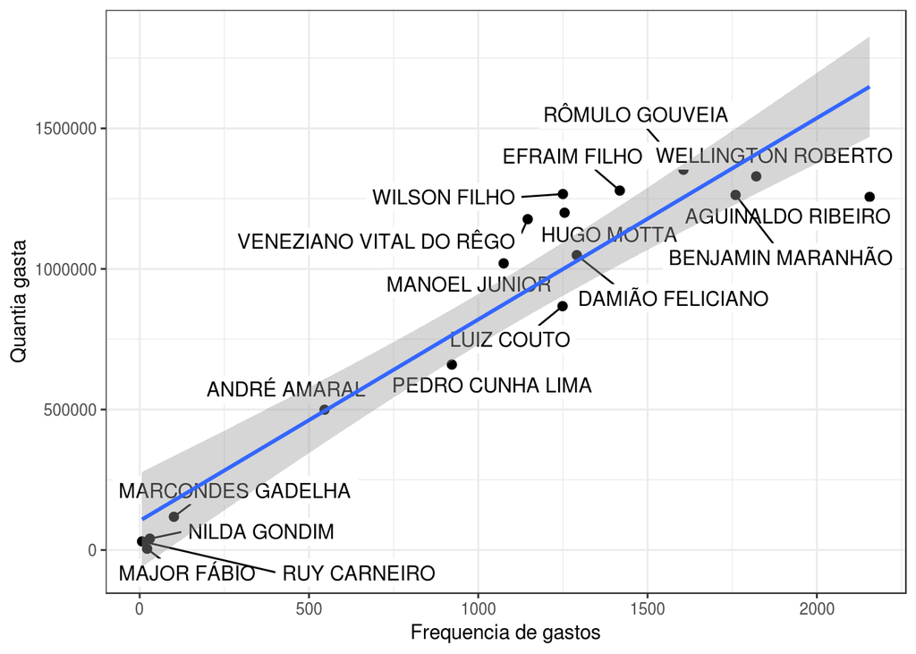

Ao ver o gráfico, podemos supor que existe correlação entre ambas as variáveis, com valor de 0.9439301.

### Questão 4: Quais os deputados que mais ultrapassam o limite de CEAP do seu estado?

Para responder essa pergunta, precisamos agrupar os gastos mensalmente. Em seguida, para cada estado, podemos ver os deputados que mais ultrapassaram a cota mensal, de estado para estado:

[figure not shown]